# Regression Models

Author

Affiliation

Manas P Panse

College of Information Science, University of Arizona

# 0 - Pre-Checks

```python
# Checking Python Version

!python --version
```

```
Python 3.12.3
```

```python
# Importing Necessary Libraries

import numpy as np
import pandas as pd
import matplotlib.pyplot as plt
import seaborn as sns
from sklearn.linear_model import LassoCV
from sklearn.linear_model import RidgeCV
from sklearn.metrics import mean_squared_error, r2_score
from sklearn.model_selection import train_test_split
from sklearn.preprocessing import StandardScaler
import statsmodels.api as sm
from statsmodels.stats.outliers_influence import variance_inflation_factor


sns.set(style = "white")
```

```python
# Importing Dataset

survival_df = pd.read_csv("data/hw-04/survivalists.csv")
```

# 1 - Data Preparation and Exploration

## Task 1 - Exploratory Data Analysis (1 Cr.)

### Data Overview

```python
survival_df.info()
```

```
<class 'pandas.core.frame.DataFrame'>
RangeIndex: 94 entries, 0 to 93
Data columns (total 16 columns):
 #   Column               Non-Null Count  Dtype
---  ------               --------------  -----
 0   season               94 non-null     int64
 1   name                 94 non-null     object
 2   age                  94 non-null     int64
 3   gender               94 non-null     object
 4   city                 94 non-null     object
 5   state                93 non-null     object
 6   country              94 non-null     object
 7   result               94 non-null     int64
 8   days_lasted          94 non-null     int64
 9   medically_evacuated  94 non-null     bool
 10  reason_tapped_out    84 non-null     object
 11  reason_category      84 non-null     object
 12  team                 14 non-null     object
 13  day_linked_up        8 non-null      float64
 14  profession           94 non-null     object
 15  url                  94 non-null     object
dtypes: bool(1), float64(1), int64(4), object(10)
memory usage: 11.2+ KB
```

#### Shape

The dataset contains **94** ROWS and **16** COLUMNS.

#### Columns

1. Categorical Columns : `name`, `gender`, `city`, `state`, `country`, `medically_evacuated`, `reason_tapped_out`, `reason_category`, `team`, `profession`, & `url`.
2. Numerical Columns : `season`, `age`, `result`, `days_lasted`, & `day_linked_up`.

[Going to include the `bool` as a categoric value.]

#### DataTypes

1. `int64` : 04 column.
2. `object` : 10 columns.
3. `bool` : 01 column.
4. `float64` : 01 columns.

### Descriptive Statistics

```python
survival_df.describe()
```

|  | season | age | result | days_lasted | day_linked_up |
| --- | --- | --- | --- | --- | --- |
| count | 94.000000 | 94.00000 | 94.000000 | 94.000000 | 8.000000 |
| mean | 4.957447 | 37.93617 | 5.276596 | 39.042553 | 9.000000 |
| std | 2.548096 | 8.84491 | 2.826161 | 27.849409 | 0.755929 |
| min | 1.000000 | 19.00000 | 1.000000 | 0.000000 | 8.000000 |
| 25% | 3.000000 | 31.00000 | 3.000000 | 10.500000 | 8.750000 |
| 50% | 5.000000 | 38.50000 | 5.000000 | 39.500000 | 9.000000 |
| 75% | 7.000000 | 44.00000 | 7.750000 | 63.750000 | 9.250000 |
| max | 9.000000 | 61.00000 | 10.000000 | 100.000000 | 10.000000 |

### Column Separations for Future Use

```python
# Numerical Columns
numeric_cols = survival_df.select_dtypes(include = ['int64', 'float64']).columns

# Categorical Columns
categoric_cols = survival_df.select_dtypes(include = ['object', 'bool']).columns
```

### Distribution of `days_lasted`

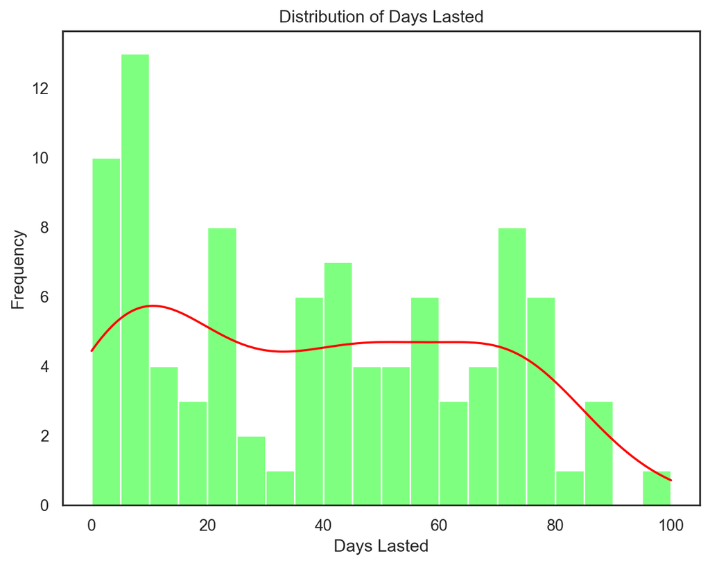

```python
plt.figure(figsize = (8, 6))
dl = sns.histplot(survival_df['days_lasted'], kde = True, bins = 20, color = 'lime')
dl.lines[0].set_color('red')
plt.title('Distribution of Days Lasted')
plt.xlabel('Days Lasted')
plt.ylabel('Frequency')
plt.show()
```

### `gender` vs `days_lasted`

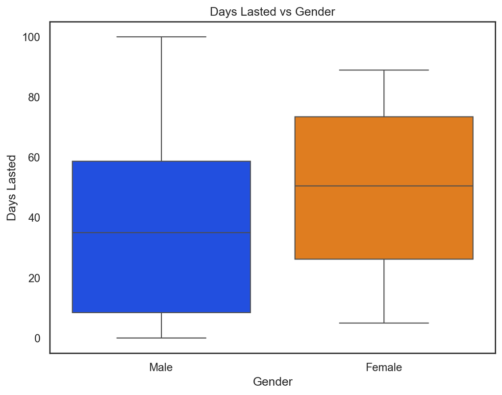

```python
plt.figure(figsize = (8, 6))
sns.boxplot(data = survival_df, x = 'gender', y = 'days_lasted', palette = 'bright')
plt.title('Days Lasted vs Gender')
plt.xlabel('Gender')
plt.ylabel('Days Lasted')
plt.show()
```

### `age` vs `days_lasted`

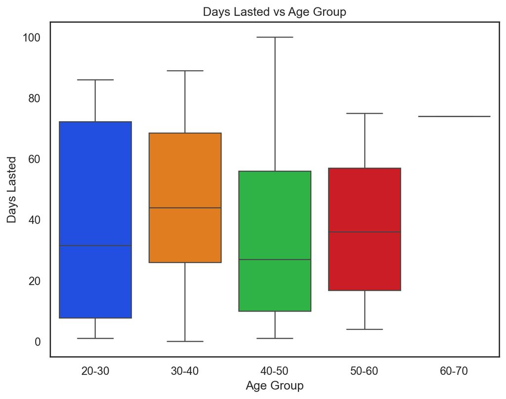

```python
age_bins = pd.cut(survival_df['age'], bins = [20, 30, 40, 50, 60, 70], labels = ["20-30", "30-40", "40-50", "50-60", "60-70"])

plt.figure(figsize = (8, 6))
sns.boxplot(x = age_bins, y = survival_df['days_lasted'], palette = 'bright')
# sns.boxplot(x = age_bins, y = survival_df['days_lasted'], palette = 'Paired')
plt.title('Days Lasted vs Age Group')
plt.xlabel('Age Group')
plt.ylabel('Days Lasted')
plt.show()
```

# 2 - Data Preprocessing

## Task 2 - Data Cleaning (1 Cr.)

### Handling Missing Values

```python
survival_df.isnull().sum()
```

```
season                  0
name                    0
age                     0
gender                  0
city                    0
state                   1
country                 0
result                  0
days_lasted             0
medically_evacuated     0
reason_tapped_out      10
reason_category        10
team                   80
day_linked_up          86
profession              0
url                     0
dtype: int64
```

```python
for col in survival_df.select_dtypes(include = ['int64', 'float64']):
    survival_df[col].fillna(survival_df[col].median(), inplace = True)

for col in survival_df.select_dtypes(include = ['object', 'bool']):
    survival_df[col].fillna(survival_df[col].mode()[0], inplace = True)
```

```python
survival_df.isnull().sum()
```

```
season                 0
name                   0
age                    0
gender                 0
city                   0
state                  0
country                0
result                 0
days_lasted            0
medically_evacuated    0
reason_tapped_out      0
reason_category        0
team                   0
day_linked_up          0
profession             0
url                    0
dtype: int64
```

### Removing Outliers

```python
# Calculate IQR for 'days_lasted'
Q1 = survival_df['days_lasted'].quantile(0.25)
Q3 = survival_df['days_lasted'].quantile(0.75)
IQR = Q3 - Q1

# Calculate bounds for detecting outliers
lower_bound = Q1 - 1.5 * IQR
upper_bound = Q3 + 1.5 * IQR

# Filter out outliers
clean_survival_df = survival_df[(survival_df['days_lasted'] >= lower_bound) & (survival_df['days_lasted'] <= upper_bound)]

# Check how many rows were removed
print(f"Before Rows : {len(survival_df)}")
print(f"Afterr Rows : {len(clean_survival_df)}")
```

```
Before Rows : 94
Afterr Rows : 94
```

## Task 3 - Data Transformation (1 Cr.)

### Feature Scaling

```python
scaler = StandardScaler()

survival_df[['age', 'days_lasted']] = scaler.fit_transform(survival_df[['age', 'days_lasted']])

survival_df[['age', 'days_lasted']].describe()
```

|  | age | days_lasted |
| --- | --- | --- |
| count | 9.400000e+01 | 9.400000e+01 |
| mean | -8.976271e-17 | 2.480285e-17 |
| std | 1.005362e+00 | 1.005362e+00 |
| min | -2.152391e+00 | -1.409434e+00 |
| 25% | -7.884039e-01 | -1.030384e+00 |
| 50% | 6.408805e-02 | 1.651380e-02 |
| 75% | 6.892488e-01 | 8.919373e-01 |
| max | 2.621564e+00 | 2.200560e+00 |

### Variable Transformation

```python
clean_survival_df['days_lasted_log'] = np.log1p(clean_survival_df['days_lasted'] + 1)

clean_survival_df[['days_lasted', 'days_lasted_log']].head()
```

|  | days_lasted | days_lasted_log |
| --- | --- | --- |
| 0 | 56 | 4.060443 |
| 1 | 55 | 4.043051 |
| 2 | 43 | 3.806662 |
| 3 | 39 | 3.713572 |
| 4 | 8 | 2.302585 |

### Histogram of `days_lasted_log`

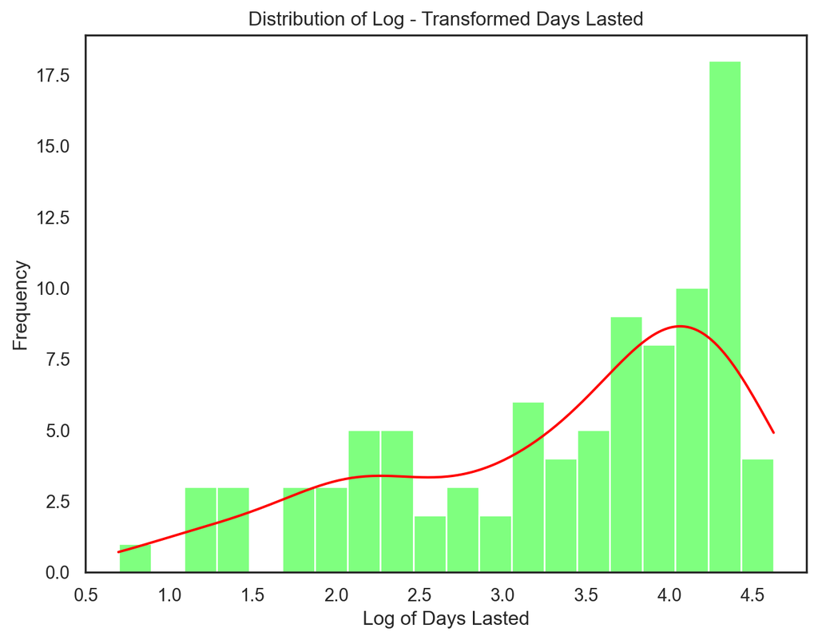

```python
plt.figure(figsize = (8, 6))
dll = sns.histplot(clean_survival_df['days_lasted_log'], kde = True, bins = 20, color = 'lime')
dll.lines[0].set_color('red')
plt.title('Distribution of Log - Transformed Days Lasted')
plt.xlabel('Log of Days Lasted')
plt.ylabel('Frequency')
plt.show()
```

### The Remaining Processing Steps

```python
# Drop irrelevant columns
survivalistsRed = clean_survival_df.drop(['name', 'city', 'url', 'profession', 'reason_tapped_out', 'state', 'country', 'reason_category', 'team', 'days_lasted'], axis = 1)

# Label encoding for 'gender'
survivalistsFinal = pd.get_dummies(survivalistsRed, columns = ['gender'], drop_first = True)

survivalistsFinal['medically_evacuated'] = survivalistsFinal['medically_evacuated'].astype(int)
survivalistsFinal['gender_Male'] = survivalistsFinal['gender_Male'].astype(int)

survivalistsFinal.info()
```

```
<class 'pandas.core.frame.DataFrame'>
RangeIndex: 94 entries, 0 to 93
Data columns (total 7 columns):
 #   Column               Non-Null Count  Dtype
---  ------               --------------  -----
 0   season               94 non-null     int64
 1   age                  94 non-null     int64
 2   result               94 non-null     int64
 3   medically_evacuated  94 non-null     int32
 4   day_linked_up        94 non-null     float64
 5   days_lasted_log      94 non-null     float64
 6   gender_Male          94 non-null     int32
dtypes: float64(2), int32(2), int64(3)
memory usage: 4.5 KB
```

# 3 - Ordinary Least Squares (OLS) Regression

## Model Building (1 Cr.)

```python
x = survivalistsFinal.drop('days_lasted_log', axis = 1)
y = survivalistsFinal['days_lasted_log']
x_train, x_test, y_train, y_test = train_test_split(x, y, test_size = 0.2, random_state = 42)
x_train_const = sm.add_constant(x_train)

ols_model = sm.OLS(y_train, x_train_const).fit()
ols_model.summary()

# NO IDEA WHY IT SHOWS THE TITLE 'OLS Regression Results' AFTER HALF OF THE RESULT !!!
```

OLS Regression Results

| Dep. Variable: | days_lasted_log | R-squared: | 0.715 |
| --- | --- | --- | --- |
| Model: | OLS | Adj. R-squared: | 0.689 |
| Method: | Least Squares | F-statistic: | 28.38 |
| Date: | Fri, 01 Nov 2024 | Prob (F-statistic): | 1.01e-16 |
| Time: | 21:14:44 | Log-Likelihood: | -60.591 |
| No. Observations: | 75 | AIC: | 135.2 |
| Df Residuals: | 68 | BIC: | 151.4 |
| Df Model: | 6 |  |  |
| Covariance Type: | nonrobust |  |  |

|  | coef | std err | t | P>\|t\| | [0.025 | 0.975] |
| --- | --- | --- | --- | --- | --- | --- |
| const | 0.2251 | 2.650 | 0.085 | 0.933 | -5.063 | 5.513 |
| season | 0.1166 | 0.026 | 4.426 | 0.000 | 0.064 | 0.169 |
| age | 0.0122 | 0.007 | 1.649 | 0.104 | -0.003 | 0.027 |
| result | -0.2645 | 0.024 | -10.876 | 0.000 | -0.313 | -0.216 |
| medically_evacuated | -0.2290 | 0.167 | -1.373 | 0.174 | -0.562 | 0.104 |
| day_linked_up | 0.4193 | 0.288 | 1.456 | 0.150 | -0.155 | 0.994 |
| gender_Male | -0.3012 | 0.175 | -1.717 | 0.091 | -0.651 | 0.049 |

| Omnibus: | 2.326 | Durbin-Watson: | 1.878 |
| --- | --- | --- | --- |
| Prob(Omnibus): | 0.313 | Jarque-Bera (JB): | 2.035 |
| Skew: | -0.403 | Prob(JB): | 0.361 |
| Kurtosis: | 2.962 | Cond. No. | 1.65e+03 |

Notes:  
[1] Standard Errors assume that the covariance matrix of the errors is correctly specified.  
[2] The condition number is large, 1.65e+03. This might indicate that there are  
strong multicollinearity or other numerical problems.

### Model Training and Evaluation (2 Cr.)

```python
x_test_const = sm.add_constant(x_test)
x_test_const = x_test_const.reindex(columns = x_train_const.columns, fill_value = 0)
y_pred = ols_model.predict(x_test_const)

mse = mean_squared_error(y_test, y_pred)
print(f"Mean Squared Error : {mse}")

r_squared = r2_score(y_test, y_pred)
print(f"R-Squared : {r_squared}")
```

```
Mean Squared Error : 0.47915396259842913
R-Squared : 0.5011470534295956
```

Interpretation -

1. MSE : **0.479**. This metric basically represents the average sq. difference between actual and predicted values. The lower this value, the better. In our case, there are still some errors in the predictions, although it might be a reasonable one given the log transformed scale of our `days_lasted_log`.
2. R-Squared : **0.501**. This metric basically explains how much was explained by the model. The higher this value, the better. In our case, our model captures half of the variability in the outcome based on the predictors.

## Task 6 - Residual Plots (1 Cr.)

```python
residuals = y_test - y_pred
```

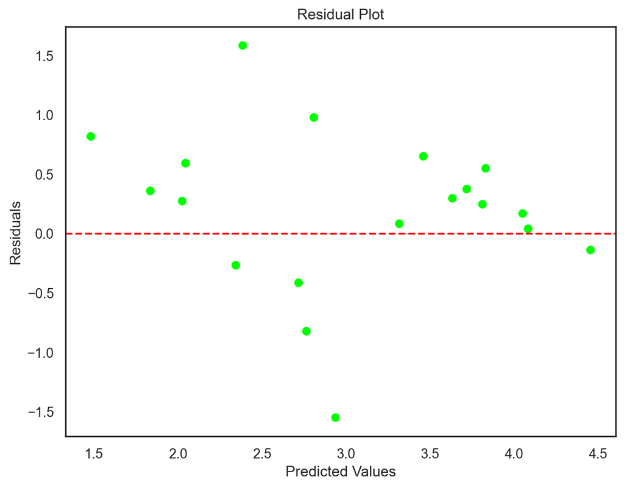

```python
plt.figure(figsize = (8, 6))
plt.scatter(y_pred, residuals, color = "lime")
plt.axhline(y = 0, color = 'red', linestyle = '--')
plt.title('Residual Plot')
plt.xlabel('Predicted Values')
plt.ylabel('Residuals')
plt.show()
```

## Task 7 - Normality of Residuals (1 Cr.)

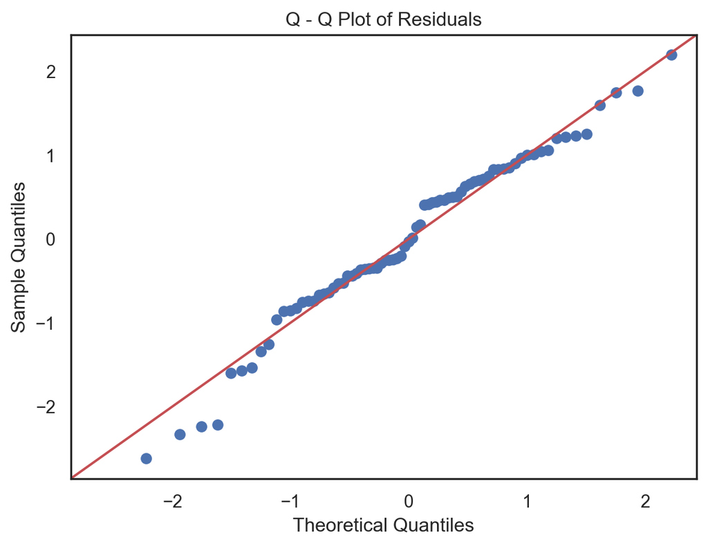

```python
residuals_train = ols_model.resid

sm.qqplot(residuals_train, line = '45', fit = True)
plt.title('Q - Q Plot of Residuals')
plt.show()
```

# 4 - Alternative Regressions

### Feature Scaling

```python
x_train_scaled = scaler.fit_transform(x_train)
x_test_scaled = scaler.transform(x_test)
```

```python
# Defining Alpha Values
alphas = [0.01, 0.1, 1, 10, 100]
```

## Task 8 - Ridge Regression (2 Cr.)

```python
ridge_cv = RidgeCV(alphas = alphas, store_cv_values = True)
ridge_cv.fit(x_train_scaled, y_train)
best_alpha_ridge = ridge_cv.alpha_

y_pred_ridge = ridge_cv.predict(x_test_scaled)
mse_ridge = mean_squared_error(y_test, y_pred_ridge)
r2_ridge = r2_score(y_test, y_pred_ridge)

print(f"Best λ (alpha)     : {best_alpha_ridge}")
print(f"Mean Squared Error : {mse_ridge}")
print(f"R-Squared          : {r2_ridge}")
```

```
Best λ (alpha)     : 1.0
Mean Squared Error : 0.43606391143638773
R-Squared          : 0.5460086233381156
```

## OPT Task - Lasso Regression

```python
lasso_cv = LassoCV(alphas = alphas, cv = 5)
lasso_cv.fit(x_train_scaled, y_train)
best_alpha_lasso = lasso_cv.alpha_

y_pred_lasso = lasso_cv.predict(x_test_scaled)
mse_lasso = mean_squared_error(y_test, y_pred_lasso)
r2_lasso = r2_score(y_test, y_pred_lasso)

print(f"Best λ (alpha)     : {best_alpha_lasso}")
print(f"Mean Squared Error : {mse_lasso}")
print(f"R-Squared          : {r2_lasso}")
```

```
Best λ (alpha)     : 0.1
Mean Squared Error : 0.4323847164869538
R-Squared          : 0.5498390773983908
```

# 5 - Declaration of Independent Work

See **HOMEPAGE** for details